# Introduction to RBi

Sebastian Funk

2016-12-20

RBi is an `R` interface to [LibBi](http://libbi.org), a library for Bayesian inference with state-space models using high-performance computer hardware.

### Latest Version: *0.5.0* (17 November 2016)

The package has been tested on macOS and Linux. It requires a working installation of **LibBI**, which is easiest done using the [homebrew-science](http://brew.sh/homebrew-science/) tap: Install [Homebrew](http://brew.sh) (on OS X) or [Linuxbrew](http://linuxbrew.sh) (on linux), then issue the following commands (using a command shell, i.e. Terminal or similar):

```bash
brew tap homebrew/science
brew install libbi
```

If you have any trouble installing **LibBi** you can get help on the [LibBi Users](https://groups.google.com/forum/#!forum/libbi-users) mailing list.

The path to the `libbi` script can be passed as an argument to **RBi**, otherwise the package tries to find it automatically using the `which` linux/unix command.

If you just want to process the output from **LibBi**, then you do not need to have **LibBi** installed.

# Installation

The **RBi** package requires `R` (>= 3.2.0) as well as the packages:

- `reshape2`
- `ncdf4`
- `data.table`

The easiest way to install the latest stable version of **RBi** is via CRAN. The package name is `rbi` (all lowercase):

```r
install.packages('rbi')
```

Alternatively, the current development version can be installed using the `devtools` package

```r
# install.packages("devtools")
library('devtools')
install_github("libbi/rbi")
```

# Loading the package

Use

```r
library('rbi')
```

to load the package.

# Getting started

The main computational engine and model grammar behind **RBi** is provided by **LibBi**. The [LibBi manual](http://libbi.org/docs/LibBi-Manual.pdf) is a good place to start for finding out everything there is to know about **LibBi** models and inference methods.

The **RBi** package mainly provides two classes: `bi_model` and `libbi`. The `bi_model` class is used to load, view and manipulate **LibBi** model files. The `libbi` class is used to run LibBi and perform inference.

The package also provides two methods for interacting with the [NetCDF](http://www.unidata.ucar.edu/software/netcdf/) files used by **LibBi**, `bi_read` and `bi_write`. Lastly, it provides a `get_traces` function to analyse Markov-chain Monte Carlo (MCMC) traces using the coda package.

# The `bi_model` class

As an example, we consider a simplified version of the SIR model discussed in [Del Moral et al. (2014)](https://arxiv.org/abs/1405.4081). This is included with the **RBi** package and can be loaded with

```r
model_file <- system.file(package="rbi", "SIR.bi") # get full file name from package
SIRmodel <- bi_model(model_file) # load model
```

The `SIRmodel` object now contains the model, which can be displayed with

```r
SIRmodel
```

```
## bi model: SIR
## =============
##  [1] "model SIR {"
##  [2] "  const h = 7"
##  [3] "  const N = 1000"
##  [4] "  const d_infection = 14"
##  [5] "  noise n_transmission"
##  [6] "  noise n_recovery"
##  [7] "  state S, I, R, Z"
##  [8] "  obs Incidence"
##  [9] "  param p_rep"
## [10] "  param p_R0"
## [11] "  sub parameter {"
## [12] "    p_rep ~ uniform(0,1)"
## [13] "    p_R0 ~ uniform(1,3)"
```

[output cut: 36 more lines]

A part of the model can be shown with, for example,

```r
SIRmodel[35:38]
```

```
## [1] "    Incidence ~ truncated_gaussian(mean = p_rep * Z, std = sqrt(p_rep * (1 - p_rep) * Z + 1), lower = 0)"
## [2] "  }"
## [3] "  sub proposal_initial {"
## [4] "    S <- N - 1"
```

or

```r
SIRmodel$get_block("parameter")
```

```
## [1] "p_rep ~ uniform(0,1)" "p_R0 ~ uniform(1,3)"
```

To get a list of states, you can use

```r
SIRmodel$get_vars("state")
```

```
## [1] "S" "I" "R" "Z"
```

Moreover, there are various methods for manipulating a model, such as `remove_block`, `add_block`, `insert_lines`, `update_lines`, `remove_lines`, `set_name`.

Lastly, `write` writes a model to a file, and `clone` creates a new `bi_model` object which is an exact copy of the original one.

# Generating a dataset

First, let’s create a data set from the SIR model.

```r
SIRdata <- bi_generate_dataset(SIRmodel, end_time=16*7, noutputs=16, seed=12345678)
```

This simulates the model a single time from time 0 until time 16*7 (e.g., 16 weeks with a daily time step), producing 16 output (one a week). Note that we have specified a seed to make this document reproducible. Remove the `seed` argument or specify a different seed to simulate your own data set.

The `bi_generate_dataset` function returns a `libbi` object:

```r
SIRdata
```

```
## Wrapper around LibBi
## * client:  sample
## * path to working folder: /var/folders/69/p5_4w84n3yg8hj0xjnjs4mv00000gq/T//RtmpVCxp8I
## * path to model file: /private/var/folders/69/p5_4w84n3yg8hj0xjnjs4mv00000gq/T/RtmpVCxp8I/SIR_model134c33b032cec.bi
## * path to output_file: /private/var/folders/69/p5_4w84n3yg8hj0xjnjs4mv00000gq/T/RtmpVCxp8I/SIR_output134c34d7a5838.nc
```

Note that, if no `working_folder` is specified, the model and output files will be stored in a temporary folder.

The generated dataset can be viewed and/or stored in a variable using `bi_read`:

```r
dataset <- bi_read(SIRdata)
```

The `bi_read` function takes the name of a NetCDF file or a `libbi` object (in which case it locates the output file) and stores the contents in a list of data frames or vectors, depending on the dimensionality of the contents:

```r
names(dataset)
```

```
##  [1] "n_transmission" "n_recovery"     "S"              "I"
##  [5] "R"              "Z"              "Incidence"      "p_rep"
##  [9] "p_R0"           "clock"
```

```r
dataset$p_R0
```

```
## [1] 2.593518
```

```r
dataset$Incidence
```

```
##    time      value
## 1     0  1.0627469
## 2     7  0.9579713
## 3    14  2.7424396
## 4    21  5.8324430
## 5    28 19.4283761
## 6    35 26.4151382
## 7    42 51.3084677
## 8    49 65.8505966
## 9    56 15.3140031
## 10   63 14.3198948
## 11   70  9.7333426
## 12   77  3.7584477
## 13   84  0.6501478
## 14   91  2.1190116
## 15   98  2.0573166
## 16  105  0.3234377
## 17  112  0.4878791
```

We can visualise the generated incidence data with

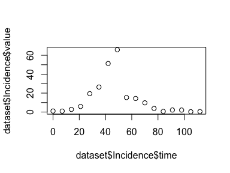

```r
plot(dataset$Incidence$time, dataset$Incidence$value)
```

# The `libbi` class

The `libbi` class manages the interaction with **LibBi** such as sampling from the prior or posterior distribution.

```r
bi <- libbi(SIRmodel)
```

This initialises a `libbi` object called `bi` with the model created earlier.

Let’s sample from the prior of the SIR mooel:

```r
bi$run(client="sample", target="prior", nsamples=1000, end_time=16*7, noutputs=16)
```

This step calls **LibBi** to sample from the prior distribution of the previously specified model, generating 1,000 samples and each time running the model for 16 * 7 = 112 time steps and writing 16 outputs (i.e., every 7 time steps). **LibBi** parses the model, creates C++ code, compiles it and run the model. If the model is run again, it should do so much quicker because it will will use the already compiled C++ code to run the model:

```r
bi$run()
```

Any call of `run` preserves options passed to the previous call of `run` and `libbi`, unless they are overwritten by arguments passed to `run` (e.g., passing a new `nsamples` argument). Let’s have a closer look at the `bi` object:

```r
str(bi)
```

```
## Reference class 'libbi' [package "rbi"] with 12 fields
##  $ client          : chr "sample"
##  $ config          : chr ""
##  $ options         :List of 4
##   ..$ target  : chr "prior"
##   ..$ nsamples: num 1000
##   ..$ end-time: num 112
##   ..$ noutputs: num 16
##  $ path_to_libbi   : Named chr "/usr/local/bin/libbi"
##   ..- attr(*, "names")= chr "libbi"
##  $ model           :Reference class 'bi_model' [package "rbi"] with 2 fields
##   ..$ model: chr [1:49] "model SIR {" "const h = 7" "const N = 1000" "const d_infection = 14" ...
##   ..$ name : chr "SIR"
##   ..and 34 methods, of which 20 are  possibly relevant:
##   ..  add_block, clean_model, clone, find_block, fix, get_block,
##   ..  get_lines, get_vars, initialize, insert_lines, obs_to_noise,
##   ..  propose_prior, remove_block, remove_lines, replace_all, set_name,
##   ..  show#envRefClass, update_lines, write, write_model_file
##  $ model_file_name : chr "/private/var/folders/69/p5_4w84n3yg8hj0xjnjs4mv00000gq/T/RtmpVCxp8I/SIR_model134c375d5d5cc.bi"
##  $ working_folder  : chr "/var/folders/69/p5_4w84n3yg8hj0xjnjs4mv00000gq/T//RtmpVCxp8I"
##  $ dims            : list()
##  $ command         : chr "cd /var/folders/69/p5_4w84n3yg8hj0xjnjs4mv00000gq/T//RtmpVCxp8I;/usr/local/bin/libbi sample --target prior --nsamples 1000 --en"| __truncated__
##  $ output_file_name: chr "/private/var/folders/69/p5_4w84n3yg8hj0xjnjs4mv00000gq/T/RtmpVCxp8I/SIR_output134c329c78084.nc"
##  $ log_file_name   : chr "/private/var/folders/69/p5_4w84n3yg8hj0xjnjs4mv00000gq/T/RtmpVCxp8I/output134c368c66f89.txt"
##  $ run_flag        : logi TRUE
##  and 18 methods, of which 4 are  possibly relevant:
##    clone, initialize, run, show#envRefClass
```

We can see it contains 12 fields: `client` is the client we passed (see LibBi manual for other clients, e.g. `filter`); `config` allows to specify an external configuration file; the `options` field contains all the options we passed to `bi$run`

```r
bi$options
```

```
## $target
## [1] "prior"
##
## $nsamples
## [1] 1000
##
## $`end-time`
## [1] 112
##
## $noutputs
## [1] 16
```

The other fields contain various bits of information about the object, including the model used, the command used to run **LibBi** (`bi$command`) and the output file name:

```r
bi$output_file_name
```

```
## [1] "/private/var/folders/69/p5_4w84n3yg8hj0xjnjs4mv00000gq/T/RtmpVCxp8I/SIR_output134c329c78084.nc"
```

We can get the results of the sampling run using `bi_read`

```r
prior <- bi_read(bi$output_file_name)
```

or with the shorthand

```r
prior <- bi_read(bi)
```

which looks at the `output_file_name` field to read in the data. Let’s look at the returned object

```r
str(prior)
```

```
## List of 9
##  $ n_transmission:'data.frame':  17000 obs. of  3 variables:
##   ..$ np   : num [1:17000] 0 0 0 0 0 0 0 0 0 0 ...
##   ..$ time : num [1:17000] 0 7 14 21 28 35 42 49 56 63 ...
##   ..$ value: num [1:17000] 0 2.091 -1.858 -0.41 -0.812 ...
##  $ n_recovery    :'data.frame':  17000 obs. of  3 variables:
##   ..$ np   : num [1:17000] 0 0 0 0 0 0 0 0 0 0 ...
##   ..$ time : num [1:17000] 0 7 14 21 28 35 42 49 56 63 ...
##   ..$ value: num [1:17000] 0 -0.415 0.899 0.154 -0.483 ...
##  $ S             :'data.frame':  17000 obs. of  3 variables:
##   ..$ np   : num [1:17000] 0 0 0 0 0 0 0 0 0 0 ...
##   ..$ time : num [1:17000] 0 7 14 21 28 35 42 49 56 63 ...
##   ..$ value: num [1:17000] 999 974 900 834 776 ...
##  $ I             :'data.frame':  17000 obs. of  3 variables:
##   ..$ np   : num [1:17000] 0 0 0 0 0 0 0 0 0 0 ...
##   ..$ time : num [1:17000] 0 7 14 21 28 35 42 49 56 63 ...
##   ..$ value: num [1:17000] 1 22.3 60.3 87 96.2 ...
##  $ R             :'data.frame':  17000 obs. of  3 variables:
##   ..$ np   : num [1:17000] 0 0 0 0 0 0 0 0 0 0 ...
##   ..$ time : num [1:17000] 0 7 14 21 28 35 42 49 56 63 ...
##   ..$ value: num [1:17000] 0 3.75 39.54 78.69 127.33 ...
##  $ Z             :'data.frame':  17000 obs. of  3 variables:
##   ..$ np   : num [1:17000] 0 0 0 0 0 0 0 0 0 0 ...
##   ..$ time : num [1:17000] 0 7 14 21 28 35 42 49 56 63 ...
##   ..$ value: num [1:17000] 1 25 73.8 65.9 57.9 ...
##  $ p_rep         :'data.frame':  1000 obs. of  2 variables:
##   ..$ np   : num [1:1000] 0 1 2 3 4 5 6 7 8 9 ...
##   ..$ value: num [1:1000] 0.949 0.934 0.947 0.44 0.387 ...
##  $ p_R0          :'data.frame':  1000 obs. of  2 variables:
##   ..$ np   : num [1:1000] 0 1 2 3 4 5 6 7 8 9 ...
##   ..$ value: num [1:1000] 2.39 1.17 2.28 1.1 2.65 ...
##  $ clock         : num 331839
```

We can see that the time-varying variables are represented as data frames with three columns: `np` (enumerating individual simulations), `time` and `value`. Parameters don’t vary in time and just have `np` and `value` columns.

# Fitting a model to data using PMCMC

Let’s perform inference using Particle Markov-chain Metropolis Hastings (PMMH). The following command will generate 16 * 10,000 = 160,000 simulations and therefore may take a little while to run.

```r
bi$options$seed <- NULL
bi$run(client="sample", target="posterior", nparticles=16, obs=SIRdata, sample_obs=TRUE, nsamples=10000)
```

This samples from the posterior distribution. Remember that options are preserved from previous runs, so we don’t need to specify `nsamples`, `end_time` and `noutputs` again, unless we want to change them. The same holds for `seed`, which is why we unset it, so that a new one is randomly generated by **LibBi**. The `nparticles` option specifies the number of particles, and the `sample_obs` option tells the `run` command that we also want observation samples from the posterior distribution of trajectories.

The time dimension (or column, if a data frame) in the passed `init`, `input` and/or `obs` files can be specified using the `time_dim` option. If this is not given, it will be assumed to be `time`, if such a dimension exists or, if not, any numeric column not called `value` (or the contents of the `value_column` option). If this does not produce a unique column name, an error will be thrown. All other dimensions/columns in the passed options will be interpreted as additional dimensions in the data, and stored in the `dims` field of the `libbi` object.

Any other options (apart from `log_file_name`, see the Debugging section) will be passed on to the command `libbi` – for a complete list, see the [LibBi manual](http://libbi.org/docs/LibBi-Manual.pdf). Hyphens can be replaced by underscores so as not to confuse R (see `end_time`). Any arguments starting with `enable`/`disable` can be specified as boolean (e.g., `assert=TRUE`). Any `dry-` options can be specified with a `"dry"` argument, e.g., `parse="dry"`.

# Analysing an MCMC run

Let’s get the results of the preceding `run` command:

```r
bi_contents(bi)
```

```
##  [1] "time"           "n_transmission" "n_recovery"     "S"
##  [5] "I"              "R"              "Z"              "p_rep"
##  [9] "p_R0"           "clock"          "loglikelihood"  "logprior"
## [13] "Incidence"
```

```r
posterior <- bi_read(bi)
str(posterior)
```

```
## List of 12
##  $ n_transmission:'data.frame':  170000 obs. of  3 variables:
##   ..$ np   : num [1:170000] 0 0 0 0 0 0 0 0 0 0 ...
##   ..$ time : num [1:170000] 0 7 14 21 28 35 42 49 56 63 ...
##   ..$ value: num [1:170000] 0 -0.5494 -0.0763 -0.70308 0.00692 ...
##  $ n_recovery    :'data.frame':  170000 obs. of  3 variables:
##   ..$ np   : num [1:170000] 0 0 0 0 0 0 0 0 0 0 ...
##   ..$ time : num [1:170000] 0 7 14 21 28 35 42 49 56 63 ...
##   ..$ value: num [1:170000] 0 1.122 0.118 0.829 -0.154 ...
##  $ S             :'data.frame':  170000 obs. of  3 variables:
##   ..$ np   : num [1:170000] 0 0 0 0 0 0 0 0 0 0 ...
##   ..$ time : num [1:170000] 0 7 14 21 28 35 42 49 56 63 ...
##   ..$ value: num [1:170000] 999 995 991 984 967 ...
##  $ I             :'data.frame':  170000 obs. of  3 variables:
##   ..$ np   : num [1:170000] 0 0 0 0 0 0 0 0 0 0 ...
##   ..$ time : num [1:170000] 0 7 14 21 28 35 42 49 56 63 ...
##   ..$ value: num [1:170000] 1 2.33 4.88 7.12 19.11 ...
##  $ R             :'data.frame':  170000 obs. of  3 variables:
##   ..$ np   : num [1:170000] 0 0 0 0 0 0 0 0 0 0 ...
##   ..$ time : num [1:170000] 0 7 14 21 28 35 42 49 56 63 ...
##   ..$ value: num [1:170000] 0 2.36 3.98 8.78 14.28 ...
##  $ Z             :'data.frame':  170000 obs. of  3 variables:
##   ..$ np   : num [1:170000] 0 0 0 0 0 0 0 0 0 0 ...
##   ..$ time : num [1:170000] 0 7 14 21 28 35 42 49 56 63 ...
##   ..$ value: num [1:170000] 1 3.69 4.17 7.04 17.49 ...
##  $ p_rep         :'data.frame':  10000 obs. of  2 variables:
##   ..$ np   : num [1:10000] 0 1 2 3 4 5 6 7 8 9 ...
##   ..$ value: num [1:10000] 0.964 0.946 0.946 0.916 0.916 ...
##  $ p_R0          :'data.frame':  10000 obs. of  2 variables:
##   ..$ np   : num [1:10000] 0 1 2 3 4 5 6 7 8 9 ...
##   ..$ value: num [1:10000] 2.33 2.28 2.28 2.01 2.01 ...
##  $ clock         : num 71553530
##  $ loglikelihood :'data.frame':  10000 obs. of  2 variables:
##   ..$ np   : num [1:10000] 0 1 2 3 4 5 6 7 8 9 ...
##   ..$ value: num [1:10000] -856 -160 -160 -102 -102 ...
##  $ logprior      :'data.frame':  10000 obs. of  2 variables:
##   ..$ np   : num [1:10000] 0 1 2 3 4 5 6 7 8 9 ...
##   ..$ value: num [1:10000] -0.693 -0.693 -0.693 -0.693 -0.693 ...
##  $ Incidence     :'data.frame':  170000 obs. of  3 variables:
##   ..$ np   : num [1:170000] 0 0 0 0 0 0 0 0 0 0 ...
##   ..$ time : num [1:170000] 0 7 14 21 28 35 42 49 56 63 ...
##   ..$ value: num [1:170000] 0 4.26 5.18 7.51 17.67 ...
```

We can see that this has three more objects than previously when we specified `target="prior"`: `loglikelihood` (the estimated log-likelihood of the parameters at each MCMC step), `logprior` (the estimated log-prior density of the parameters at each MCMC step), and `Incidence` (sampled observations, as we specified `sample_obs=TRUE`).

To analyse MCMC outputs, we can use the **coda** package and the `get_traces` function of **RBi**:

```r
library(coda)
traces <- mcmc(get_traces(bi))
```

We can study, for example, the acceptance rate

```r
accRate <- 1 - rejectionRate(traces)
accRate
```

```
##     p_rep      p_R0
## 0.1719172 0.1719172
```

and visualise parameter traces and densities with

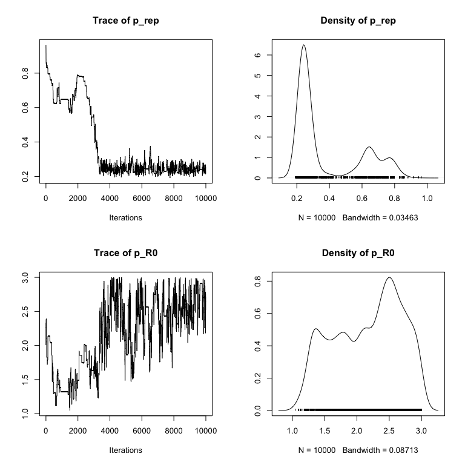

```r
plot(traces)
```

Compare this to the marginal posterior distributions to the “correct” parameters used to generate the data set:

```r
dataset[bi$model$get_vars("param")]
```

```
## $p_rep
## [1] 0.2458042
##
## $p_R0
## [1] 2.593518
```

For more details on using **coda** to further analyse the chains, see the website of the [coda package](https://cran.r-project.org/package=coda). For more plotting functionality, see the `plot_libbi` function in [RBi.helpers](https://github.com/sbfnk/rbi.helpers).

# Debugging

If `libbi` throws an error, it is best to investigate with `verbose = TRUE`, and setting `working_folder` to a folder that one can then use for debugging. Output of the `libbi` call can be saved in a file using the `log_file_name` option (by default a temporary file).

# Related packages

[RBi.helpers](https://github.com/sbfnk/rbi.helpers) contains higher-level methods to interact with libbi, including methods for plotting the results of libbi runs and for adapting the proposal distribution and number of particles.

# References

- Murray, L.M. (2013). [Bayesian state-space modelling on high-performance hardware using LibBi](https://arxiv.org/abs/1306.3277).